# (Ford GoBike System Data Exploration )

## Investigation Overview

> In this project, the Ford GoBike dataset will be used to apply the concept of data visualization

## Dataset Overview

> Ford GoBike is a regional public bicycle sharing system in California's San Francisco Bay Area. The GoBike dataset was collected from 2017 to 2019. The dataset includes all the information about each trip, such as trip duration, the start and end time for the trip, the station id, name, and the coordination for the location. In this system, there is to type of user, either customer or subscriber, which is included in the dataset also as one of the variables.

```python
# import all packages and set plots to be embedded inline
import numpy as np
import pandas as pd
import matplotlib.pyplot as plt
import seaborn as sb


%matplotlib inline
```

```python
# Load the ford go bike dataset
df = pd.read_csv('2017-fordgobike-tripdata.csv')
```

```python
# Show the dataset
df.head(6)
```

|  | duration_sec | start_time | end_time | start_station_id | start_station_name | start_station_latitude | start_station_longitude | end_station_id | end_station_name | end_station_latitude | end_station_longitude | bike_id | user_type |
| --- | --- | --- | --- | --- | --- | --- | --- | --- | --- | --- | --- | --- | --- |
| 0 | 80110 | 2017-12-31 16:57:39.6540 | 2018-01-01 15:12:50.2450 | 74 | Laguna St at Hayes St | 37.776435 | -122.426244 | 43 | San Francisco Public Library (Grove St at Hyde... | 37.778768 | -122.415929 | 96 | Customer |
| 1 | 78800 | 2017-12-31 15:56:34.8420 | 2018-01-01 13:49:55.6170 | 284 | Yerba Buena Center for the Arts (Howard St at ... | 37.784872 | -122.400876 | 96 | Dolores St at 15th St | 37.766210 | -122.426614 | 88 | Customer |
| 2 | 45768 | 2017-12-31 22:45:48.4110 | 2018-01-01 11:28:36.8830 | 245 | Downtown Berkeley BART | 37.870348 | -122.267764 | 245 | Downtown Berkeley BART | 37.870348 | -122.267764 | 1094 | Customer |
| 3 | 62172 | 2017-12-31 17:31:10.6360 | 2018-01-01 10:47:23.5310 | 60 | 8th St at Ringold St | 37.774520 | -122.409449 | 5 | Powell St BART Station (Market St at 5th St) | 37.783899 | -122.408445 | 2831 | Customer |
| 4 | 43603 | 2017-12-31 14:23:14.0010 | 2018-01-01 02:29:57.5710 | 239 | Bancroft Way at Telegraph Ave | 37.868813 | -122.258764 | 247 | Fulton St at Bancroft Way | 37.867789 | -122.265896 | 3167 | Subscriber |
| 5 | 9226 | 2017-12-31 22:51:00.9180 | 2018-01-01 01:24:47.1660 | 30 | San Francisco Caltrain (Townsend St at 4th St) | 37.776598 | -122.395282 | 30 | San Francisco Caltrain (Townsend St at 4th St) | 37.776598 | -122.395282 | 1487 | Customer |

```python
# Show the dataset
df.tail(6)
```

|  | duration_sec | start_time | end_time | start_station_id | start_station_name | start_station_latitude | start_station_longitude | end_station_id | end_station_name | end_station_latitude | end_station_longitude | bike_id | user_type |
| --- | --- | --- | --- | --- | --- | --- | --- | --- | --- | --- | --- | --- | --- |
| 519694 | 730 | 2017-06-28 09:58:33.6690 | 2017-06-28 10:10:44.2130 | 23 | The Embarcadero at Steuart St | 37.791464 | -122.391034 | 44 | Civic Center/UN Plaza BART Station (Market St ... | 37.781074 | -122.411738 | 272 | Subscriber |
| 519695 | 435 | 2017-06-28 10:00:54.5280 | 2017-06-28 10:08:10.4380 | 81 | Berry St at 4th St | 37.775880 | -122.393170 | 45 | 5th St at Howard St | 37.781752 | -122.405127 | 400 | Subscriber |
| 519696 | 431 | 2017-06-28 09:56:39.6310 | 2017-06-28 10:03:51.0900 | 66 | 3rd St at Townsend St | 37.778742 | -122.392741 | 321 | 5th at Folsom | 37.780146 | -122.403071 | 316 | Subscriber |
| 519697 | 424 | 2017-06-28 09:47:36.3470 | 2017-06-28 09:54:41.1870 | 21 | Montgomery St BART Station (Market St at 2nd St) | 37.789625 | -122.400811 | 48 | 2nd St at S Park St | 37.782411 | -122.392706 | 240 | Subscriber |
| 519698 | 366 | 2017-06-28 09:47:41.6640 | 2017-06-28 09:53:47.7150 | 58 | Market St at 10th St | 37.776619 | -122.417385 | 59 | S Van Ness Ave at Market St | 37.774814 | -122.418954 | 669 | Subscriber |
| 519699 | 188 | 2017-06-28 09:49:46.3770 | 2017-06-28 09:52:55.3380 | 25 | Howard St at 2nd St | 37.787522 | -122.397405 | 48 | 2nd St at S Park St | 37.782411 | -122.392706 | 117 | Subscriber |

```python
# Show the dataset
df.sample(6)
```

|  | duration_sec | start_time | end_time | start_station_id | start_station_name | start_station_latitude | start_station_longitude | end_station_id | end_station_name | end_station_latitude | end_station_longitude | bike_id | user_type |
| --- | --- | --- | --- | --- | --- | --- | --- | --- | --- | --- | --- | --- | --- |
| 6206 | 420 | 2017-12-28 09:56:55.1010 | 2017-12-28 10:03:56.0240 | 81 | Berry St at 4th St | 37.775880 | -122.393170 | 36 | Folsom St at 3rd St | 37.783830 | -122.398870 | 3594 | Subscriber |
| 125978 | 352 | 2017-11-17 08:58:55.4080 | 2017-11-17 09:04:47.4700 | 59 | S Van Ness Ave at Market St | 37.774814 | -122.418954 | 88 | 11th St at Bryant St | 37.770030 | -122.411726 | 3128 | Subscriber |
| 437225 | 1116 | 2017-08-15 18:30:45.1590 | 2017-08-15 18:49:21.6950 | 50 | 2nd St at Townsend St - Coming Soon | 37.780526 | -122.390288 | 58 | Market St at 10th St | 37.776619 | -122.417385 | 2395 | Subscriber |
| 378490 | 518 | 2017-09-05 16:34:57.4370 | 2017-09-05 16:43:36.0230 | 30 | San Francisco Caltrain (Townsend St at 4th St) | 37.776598 | -122.395282 | 100 | Bryant St at 15th St | 37.767100 | -122.410662 | 2937 | Subscriber |
| 410552 | 836 | 2017-08-25 07:34:15.3050 | 2017-08-25 07:48:11.3540 | 85 | Church St at Duboce Ave | 37.770083 | -122.429156 | 21 | Montgomery St BART Station (Market St at 2nd St) | 37.789625 | -122.400811 | 896 | Subscriber |
| 62121 | 790 | 2017-12-07 18:23:50.9040 | 2017-12-07 18:37:00.9480 | 89 | Division St at Potrero Ave | 37.769218 | -122.407646 | 133 | Valencia St at 22nd St | 37.755213 | -122.420975 | 2338 | Subscriber |

```python
# Read dataset general information
df.info()
```

```
<class 'pandas.core.frame.DataFrame'>
RangeIndex: 519700 entries, 0 to 519699
Data columns (total 13 columns):
 #   Column                   Non-Null Count   Dtype
---  ------                   --------------   -----
 0   duration_sec             519700 non-null  int64
 1   start_time               519700 non-null  object
 2   end_time                 519700 non-null  object
 3   start_station_id         519700 non-null  int64
 4   start_station_name       519700 non-null  object
 5   start_station_latitude   519700 non-null  float64
 6   start_station_longitude  519700 non-null  float64
 7   end_station_id           519700 non-null  int64
 8   end_station_name         519700 non-null  object
 9   end_station_latitude     519700 non-null  float64
 10  end_station_longitude    519700 non-null  float64
 11  bike_id                  519700 non-null  int64
 12  user_type                519700 non-null  object
dtypes: float64(4), int64(4), object(5)
memory usage: 51.5+ MB
```

```python
# Read descriptive data statistics
df.describe()
```

|  | duration_sec | start_station_id | start_station_latitude | start_station_longitude | end_station_id | end_station_latitude | end_station_longitude | bike_id |
| --- | --- | --- | --- | --- | --- | --- | --- | --- |
| count | 519700.000000 | 519700.000000 | 519700.000000 | 519700.000000 | 519700.000000 | 519700.000000 | 519700.000000 | 519700.000000 |
| mean | 1099.009521 | 95.034245 | 37.771653 | -122.363927 | 92.184041 | 37.771844 | -122.363236 | 1672.533079 |
| std | 3444.146451 | 86.083078 | 0.086305 | 0.105573 | 84.969491 | 0.086224 | 0.105122 | 971.356959 |
| min | 61.000000 | 3.000000 | 37.317298 | -122.444293 | 3.000000 | 37.317298 | -122.444293 | 10.000000 |
| 25% | 382.000000 | 24.000000 | 37.773492 | -122.411726 | 23.000000 | 37.774520 | -122.410345 | 787.000000 |
| 50% | 596.000000 | 67.000000 | 37.783521 | -122.398870 | 66.000000 | 37.783830 | -122.398525 | 1728.500000 |
| 75% | 938.000000 | 139.000000 | 37.795392 | -122.391034 | 134.000000 | 37.795392 | -122.391034 | 2520.000000 |
| max | 86369.000000 | 340.000000 | 37.880222 | -121.874119 | 340.000000 | 37.880222 | -121.874119 | 3733.000000 |

```python
# Check the duplicated
df.duplicated().sum()
```

```
0
```

```python
# Check the null values
df.isnull().sum()
```

```
duration_sec               0
start_time                 0
end_time                   0
start_station_id           0
start_station_name         0
start_station_latitude     0
start_station_longitude    0
end_station_id             0
end_station_name           0
end_station_latitude       0
end_station_longitude      0
bike_id                    0
user_type                  0
dtype: int64
```

```python
# Count each user type
df['user_type'].value_counts()
```

```
Subscriber    409230
Customer      110470
Name: user_type, dtype: int64
```

```python
# Make a copy of the tables before cleaning
df_clean = df.copy()
```

```python
# Change data type
df_clean['start_time'] = pd.to_datetime(df_clean['start_time'])
df_clean['end_time'] = pd.to_datetime(df_clean['end_time'])
df_clean['start_station_id'] = df_clean['start_station_id'].astype('str')
df_clean['bike_id'] = df_clean['bike_id'].astype('str')
df_clean['end_station_id'] = df_clean['end_station_id'].astype('str')
```

```python
# Calculate the duration manually
df_clean['diff'] = df_clean['end_time'] - df_clean['start_time']
```

```python
# Convert to seconds
df_clean['diff'] = df_clean['diff'].dt.total_seconds()
```

```python
# Change data type
df_clean['diff'] = df_clean['diff'].astype('int64')
```

```python
# Show data
df_clean.head(50)
```

|  | duration_sec | start_time | end_time | start_station_id | start_station_name | start_station_latitude | start_station_longitude | end_station_id | end_station_name | end_station_latitude | end_station_longitude | bike_id | user_type | diff |
| --- | --- | --- | --- | --- | --- | --- | --- | --- | --- | --- | --- | --- | --- | --- |
| 0 | 80110 | 2017-12-31 16:57:39.654 | 2018-01-01 15:12:50.245 | 74 | Laguna St at Hayes St | 37.776435 | -122.426244 | 43 | San Francisco Public Library (Grove St at Hyde... | 37.778768 | -122.415929 | 96 | Customer | 80110 |
| 1 | 78800 | 2017-12-31 15:56:34.842 | 2018-01-01 13:49:55.617 | 284 | Yerba Buena Center for the Arts (Howard St at ... | 37.784872 | -122.400876 | 96 | Dolores St at 15th St | 37.766210 | -122.426614 | 88 | Customer | 78800 |
| 2 | 45768 | 2017-12-31 22:45:48.411 | 2018-01-01 11:28:36.883 | 245 | Downtown Berkeley BART | 37.870348 | -122.267764 | 245 | Downtown Berkeley BART | 37.870348 | -122.267764 | 1094 | Customer | 45768 |
| 3 | 62172 | 2017-12-31 17:31:10.636 | 2018-01-01 10:47:23.531 | 60 | 8th St at Ringold St | 37.774520 | -122.409449 | 5 | Powell St BART Station (Market St at 5th St) | 37.783899 | -122.408445 | 2831 | Customer | 62172 |
| 4 | 43603 | 2017-12-31 14:23:14.001 | 2018-01-01 02:29:57.571 | 239 | Bancroft Way at Telegraph Ave | 37.868813 | -122.258764 | 247 | Fulton St at Bancroft Way | 37.867789 | -122.265896 | 3167 | Subscriber | 43603 |
| 5 | 9226 | 2017-12-31 22:51:00.918 | 2018-01-01 01:24:47.166 | 30 | San Francisco Caltrain (Townsend St at 4th St) | 37.776598 | -122.395282 | 30 | San Francisco Caltrain (Townsend St at 4th St) | 37.776598 | -122.395282 | 1487 | Customer | 9226 |
| 6 | 4507 | 2017-12-31 23:49:28.422 | 2018-01-01 01:04:35.619 | 259 | Addison St at Fourth St | 37.866249 | -122.299371 | 259 | Addison St at Fourth St | 37.866249 | -122.299371 | 3539 | Customer | 4507 |
| 7 | 4334 | 2017-12-31 23:46:37.196 | 2018-01-01 00:58:51.211 | 284 | Yerba Buena Center for the Arts (Howard St at ... | 37.784872 | -122.400876 | 284 | Yerba Buena Center for the Arts (Howard St at ... | 37.784872 | -122.400876 | 1503 | Customer | 4334 |
| 8 | 4150 | 2017-12-31 23:37:07.548 | 2018-01-01 00:46:18.308 | 20 | Mechanics Monument Plaza (Market St at Bush St) | 37.791300 | -122.399051 | 20 | Mechanics Monument Plaza (Market St at Bush St) | 37.791300 | -122.399051 | 3125 | Customer | 4150 |
| 9 | 4238 | 2017-12-31 23:35:38.145 | 2018-01-01 00:46:17.053 | 20 | Mechanics Monument Plaza (Market St at Bush St) | 37.791300 | -122.399051 | 20 | Mechanics Monument Plaza (Market St at Bush St) | 37.791300 | -122.399051 | 2543 | Customer | 4238 |
| 10 | 3292 | 2017-12-31 23:46:32.403 | 2018-01-01 00:41:24.605 | 284 | Yerba Buena Center for the Arts (Howard St at ... | 37.784872 | -122.400876 | 22 | Howard St at Beale St | 37.789756 | -122.394643 | 3058 | Customer | 3292 |
| 11 | 3177 | 2017-12-31 23:48:11.757 | 2018-01-01 00:41:09.581 | 284 | Yerba Buena Center for the Arts (Howard St at ... | 37.784872 | -122.400876 | 22 | Howard St at Beale St | 37.789756 | -122.394643 | 3197 | Customer | 3177 |
| 12 | 2183 | 2017-12-31 23:52:55.581 | 2018-01-01 00:29:18.743 | 67 | San Francisco Caltrain Station 2 (Townsend St... | 37.776639 | -122.395526 | 24 | Spear St at Folsom St | 37.789677 | -122.390428 | 2311 | Subscriber | 2183 |
| 13 | 2170 | 2017-12-31 23:52:55.937 | 2018-01-01 00:29:06.924 | 67 | San Francisco Caltrain Station 2 (Townsend St... | 37.776639 | -122.395526 | 24 | Spear St at Folsom St | 37.789677 | -122.390428 | 3717 | Subscriber | 2170 |
| 14 | 2697 | 2017-12-31 23:35:23.222 | 2018-01-01 00:20:20.813 | 66 | 3rd St at Townsend St | 37.778742 | -122.392741 | 23 | The Embarcadero at Steuart St | 37.791464 | -122.391034 | 3452 | Customer | 2697 |
| 15 | 1544 | 2017-12-31 23:53:38.943 | 2018-01-01 00:19:23.047 | 14 | Clay St at Battery St | 37.795001 | -122.399970 | 27 | Beale St at Harrison St | 37.788059 | -122.391865 | 558 | Subscriber | 1544 |
| 16 | 1474 | 2017-12-31 23:54:40.146 | 2018-01-01 00:19:14.351 | 14 | Clay St at Battery St | 37.795001 | -122.399970 | 27 | Beale St at Harrison St | 37.788059 | -122.391865 | 3646 | Subscriber | 1474 |
| 17 | 1397 | 2017-12-31 23:55:09.686 | 2018-01-01 00:18:26.721 | 78 | Folsom St at 9th St | 37.773717 | -122.411647 | 15 | San Francisco Ferry Building (Harry Bridges Pl... | 37.795392 | -122.394203 | 1667 | Customer | 1397 |
| 18 | 1532 | 2017-12-31 23:52:49.497 | 2018-01-01 00:18:21.953 | 78 | Folsom St at 9th St | 37.773717 | -122.411647 | 15 | San Francisco Ferry Building (Harry Bridges Pl... | 37.795392 | -122.394203 | 3114 | Subscriber | 1532 |
| 19 | 1216 | 2017-12-31 23:46:33.993 | 2018-01-01 00:06:50.058 | 4 | Cyril Magnin St at Ellis St | 37.785881 | -122.408915 | 123 | Folsom St at 19th St | 37.760594 | -122.414817 | 1473 | Subscriber | 1216 |
| 20 | 386 | 2017-12-31 23:59:01.261 | 2018-01-01 00:05:27.809 | 317 | San Salvador St at 9th St | 37.333955 | -121.877349 | 296 | 5th St at Virginia St | 37.325998 | -121.877120 | 1603 | Subscriber | 386 |
| 21 | 4174 | 2017-12-31 22:52:22.286 | 2018-01-01 00:01:56.614 | 30 | San Francisco Caltrain (Townsend St at 4th St) | 37.776598 | -122.395282 | 6 | The Embarcadero at Sansome St | 37.804770 | -122.403234 | 809 | Customer | 4174 |
| 22 | 422 | 2017-12-31 23:54:25.337 | 2018-01-01 00:01:27.354 | 139 | Garfield Square (25th St at Harrison St) | 37.751017 | -122.411901 | 99 | Folsom St at 15th St | 37.767037 | -122.415443 | 2415 | Subscriber | 422 |
| 23 | 1165 | 2017-12-31 23:35:55.543 | 2017-12-31 23:55:21.220 | 66 | 3rd St at Townsend St | 37.778742 | -122.392741 | 23 | The Embarcadero at Steuart St | 37.791464 | -122.391034 | 3671 | Customer | 1165 |
| 24 | 1149 | 2017-12-31 23:36:03.555 | 2017-12-31 23:55:13.465 | 66 | 3rd St at Townsend St | 37.778742 | -122.392741 | 23 | The Embarcadero at Steuart St | 37.791464 | -122.391034 | 3375 | Customer | 1149 |
| 25 | 1130 | 2017-12-31 23:36:16.069 | 2017-12-31 23:55:06.096 | 66 | 3rd St at Townsend St | 37.778742 | -122.392741 | 23 | The Embarcadero at Steuart St | 37.791464 | -122.391034 | 2721 | Customer | 1130 |
| 26 | 1003 | 2017-12-31 23:36:34.548 | 2017-12-31 23:53:18.195 | 66 | 3rd St at Townsend St | 37.778742 | -122.392741 | 23 | The Embarcadero at Steuart St | 37.791464 | -122.391034 | 2522 | Customer | 1003 |
| 27 | 862 | 2017-12-31 23:38:24.874 | 2017-12-31 23:52:47.542 | 6 | The Embarcadero at Sansome St | 37.804770 | -122.403234 | 15 | San Francisco Ferry Building (Harry Bridges Pl... | 37.795392 | -122.394203 | 533 | Customer | 862 |
| 28 | 871 | 2017-12-31 23:37:47.192 | 2017-12-31 23:52:18.473 | 323 | Broadway at Kearny | 37.798014 | -122.405950 | 14 | Clay St at Battery St | 37.795001 | -122.399970 | 1456 | Subscriber | 871 |
| 29 | 784 | 2017-12-31 23:39:13.084 | 2017-12-31 23:52:17.293 | 6 | The Embarcadero at Sansome St | 37.804770 | -122.403234 | 15 | San Francisco Ferry Building (Harry Bridges Pl... | 37.795392 | -122.394203 | 1691 | Customer | 784 |
| 30 | 767 | 2017-12-31 23:39:29.839 | 2017-12-31 23:52:17.122 | 6 | The Embarcadero at Sansome St | 37.804770 | -122.403234 | 15 | San Francisco Ferry Building (Harry Bridges Pl... | 37.795392 | -122.394203 | 1568 | Customer | 767 |
| 31 | 5193 | 2017-12-31 22:25:08.572 | 2017-12-31 23:51:42.380 | 49 | S Park St at 3rd St | 37.780760 | -122.394989 | 11 | Davis St at Jackson St | 37.797280 | -122.398436 | 2823 | Customer | 5193 |
| 32 | 733 | 2017-12-31 23:38:38.861 | 2017-12-31 23:50:52.504 | 323 | Broadway at Kearny | 37.798014 | -122.405950 | 14 | Clay St at Battery St | 37.795001 | -122.399970 | 1634 | Subscriber | 733 |
| 33 | 781 | 2017-12-31 23:33:52.981 | 2017-12-31 23:46:54.972 | 251 | California St at University Ave | 37.870555 | -122.279720 | 259 | Addison St at Fourth St | 37.866249 | -122.299371 | 3539 | Customer | 781 |
| 34 | 475 | 2017-12-31 23:37:35.545 | 2017-12-31 23:45:30.808 | 7 | Frank H Ogawa Plaza | 37.804562 | -122.271738 | 230 | 14th St at Mandela Pkwy | 37.810743 | -122.291415 | 3598 | Subscriber | 475 |
| 35 | 152 | 2017-12-31 23:41:32.917 | 2017-12-31 23:44:05.047 | 96 | Dolores St at 15th St | 37.766210 | -122.426614 | 86 | Market St at Dolores St | 37.769305 | -122.426826 | 2728 | Subscriber | 152 |
| 36 | 249 | 2017-12-31 23:38:37.736 | 2017-12-31 23:42:47.211 | 278 | The Alameda at Bush St | 37.331932 | -121.904888 | 314 | Santa Clara St at Almaden Blvd | 37.333988 | -121.894902 | 47 | Subscriber | 249 |
| 37 | 2511 | 2017-12-31 22:58:26.524 | 2017-12-31 23:40:17.987 | 30 | San Francisco Caltrain (Townsend St at 4th St) | 37.776598 | -122.395282 | 6 | The Embarcadero at Sansome St | 37.804770 | -122.403234 | 3329 | Customer | 2511 |
| 38 | 2896 | 2017-12-31 22:51:00.751 | 2017-12-31 23:39:17.543 | 30 | San Francisco Caltrain (Townsend St at 4th St) | 37.776598 | -122.395282 | 6 | The Embarcadero at Sansome St | 37.804770 | -122.403234 | 970 | Customer | 2896 |
| 39 | 243 | 2017-12-31 23:34:46.302 | 2017-12-31 23:38:49.303 | 182 | 19th Street BART Station | 37.809013 | -122.268247 | 195 | Bay Pl at Vernon St | 37.812314 | -122.260779 | 2674 | Subscriber | 243 |
| 40 | 833 | 2017-12-31 23:24:48.513 | 2017-12-31 23:38:41.520 | 98 | Valencia St at 16th St | 37.765052 | -122.421866 | 62 | Victoria Manalo Draves Park | 37.777791 | -122.406432 | 1227 | Subscriber | 833 |
| 41 | 820 | 2017-12-31 23:24:49.373 | 2017-12-31 23:38:29.829 | 98 | Valencia St at 16th St | 37.765052 | -122.421866 | 62 | Victoria Manalo Draves Park | 37.777791 | -122.406432 | 3595 | Subscriber | 820 |
| 42 | 602 | 2017-12-31 23:26:51.153 | 2017-12-31 23:36:53.456 | 19 | Post St at Kearny St | 37.788975 | -122.403452 | 16 | Steuart St at Market St | 37.794130 | -122.394430 | 2828 | Customer | 602 |
| 43 | 1269 | 2017-12-31 23:15:14.580 | 2017-12-31 23:36:23.608 | 66 | 3rd St at Townsend St | 37.778742 | -122.392741 | 23 | The Embarcadero at Steuart St | 37.791464 | -122.391034 | 3344 | Customer | 1269 |
| 44 | 1247 | 2017-12-31 23:15:31.514 | 2017-12-31 23:36:19.216 | 66 | 3rd St at Townsend St | 37.778742 | -122.392741 | 23 | The Embarcadero at Steuart St | 37.791464 | -122.391034 | 1019 | Customer | 1247 |
| 45 | 5290 | 2017-12-31 22:06:44.415 | 2017-12-31 23:34:54.458 | 42 | San Francisco City Hall (Polk St at Grove St) | 37.778650 | -122.418230 | 8 | The Embarcadero at Vallejo St | 37.799953 | -122.398525 | 1717 | Customer | 5290 |
| 46 | 538 | 2017-12-31 23:24:34.580 | 2017-12-31 23:33:33.475 | 85 | Church St at Duboce Ave | 37.770083 | -122.429156 | 120 | Mission Dolores Park | 37.761420 | -122.426435 | 1780 | Customer | 538 |
| 47 | 577 | 2017-12-31 23:20:38.013 | 2017-12-31 23:30:15.883 | 124 | 19th St at Florida St | 37.760447 | -122.410807 | 134 | Valencia St at 24th St | 37.752428 | -122.420628 | 3067 | Subscriber | 577 |
| 48 | 418 | 2017-12-31 23:22:04.850 | 2017-12-31 23:29:03.008 | 249 | Russell St at College Ave | 37.858473 | -122.253253 | 172 | College Ave at Taft Ave | 37.841800 | -122.251535 | 1439 | Subscriber | 418 |
| 49 | 782 | 2017-12-31 23:15:25.758 | 2017-12-31 23:28:28.372 | 6 | The Embarcadero at Sansome St | 37.804770 | -122.403234 | 6 | The Embarcadero at Sansome St | 37.804770 | -122.403234 | 1691 | Customer | 782 |

```python
# Check if the given duration equal to calculated duration
k=0;
not_matching =[]
for k in range(df_clean.shape[0]):
    if df_clean['duration_sec'].loc[k] == df_clean['duration_sec'].loc[k]:
        not_matching += [1]
        k=k+1
    else:
        not_matching += [0]
        k=k+1
```

```python
# Number of mathced records
sum(not_matching)
```

```
519700
```

```python
# Create distance coulmn
from math import sin, cos, sqrt, atan2, radians

def distance (lat1,lon1,lat2,lon2):
    R = 6373.0

    lat1 = radians(lat1)
    lon1 = radians(lon1)
    lat2 = radians(lat2)
    lon2 = radians(lon2)

    dlon = lon2 - lon1
    dlat = lat2 - lat1

    a = sin(dlat / 2)**2 + cos(lat1) * cos(lat2) * sin(dlon / 2)**2
    c = 2 * atan2(sqrt(a), sqrt(1 - a))

    distance = R * c
    return np.float64(round(1000*distance))
```

```python
df_clean['distance'] = df_clean.apply(lambda row: distance(row['start_station_latitude'],row['start_station_longitude'],row['end_station_latitude'],row['end_station_longitude']),axis=1)
```

```python
# Drop zero distance
df_clean = df_clean[df_clean['distance'] != 0]
```

```python
df_clean['distance'].value_counts()
```

```
1311.0    5161
1414.0    4259
1073.0    3536
2172.0    3125
752.0     3105
          ...
3537.0       1
5028.0       1
4976.0       1
3827.0       1
6095.0       1
Name: distance, Length: 4590, dtype: int64
```

```python
# Read descriptive data statistics
df_clean.describe()
```

|  | duration_sec | start_station_latitude | start_station_longitude | end_station_latitude | end_station_longitude | diff | distance |
| --- | --- | --- | --- | --- | --- | --- | --- |
| count | 501566.000000 | 501566.000000 | 501566.000000 | 501566.000000 | 501566.000000 | 501566.000000 | 501566.000000 |
| mean | 996.687698 | 37.772223 | -122.365537 | 37.772421 | -122.364821 | 996.615925 | 1644.974382 |
| std | 3143.980066 | 0.084102 | 0.103358 | 0.084015 | 0.102892 | 3142.612091 | 981.859418 |
| min | 61.000000 | 37.317298 | -122.444293 | 37.317298 | -122.444293 | -3307.000000 | 13.000000 |
| 25% | 380.000000 | 37.773507 | -122.411738 | 37.774520 | -122.410345 | 380.000000 | 951.000000 |
| 50% | 587.000000 | 37.782411 | -122.398870 | 37.783813 | -122.398773 | 587.000000 | 1426.000000 |
| 75% | 906.000000 | 37.795392 | -122.391198 | 37.795392 | -122.391198 | 906.000000 | 2089.000000 |
| max | 86355.000000 | 37.880222 | -121.874119 | 37.880222 | -121.874119 | 86355.000000 | 68208.000000 |

```python
# Read dataset general information
df_clean.info()
```

```
<class 'pandas.core.frame.DataFrame'>
Int64Index: 501566 entries, 0 to 519699
Data columns (total 15 columns):
 #   Column                   Non-Null Count   Dtype
---  ------                   --------------   -----
 0   duration_sec             501566 non-null  int64
 1   start_time               501566 non-null  datetime64[ns]
 2   end_time                 501566 non-null  datetime64[ns]
 3   start_station_id         501566 non-null  object
 4   start_station_name       501566 non-null  object
 5   start_station_latitude   501566 non-null  float64
 6   start_station_longitude  501566 non-null  float64
 7   end_station_id           501566 non-null  object
 8   end_station_name         501566 non-null  object
 9   end_station_latitude     501566 non-null  float64
 10  end_station_longitude    501566 non-null  float64
 11  bike_id                  501566 non-null  object
 12  user_type                501566 non-null  object
 13  diff                     501566 non-null  int64
 14  distance                 501566 non-null  float64
dtypes: datetime64[ns](2), float64(5), int64(2), object(6)
memory usage: 61.2+ MB
```

```python
#Show data
df_clean.head()
```

|  | duration_sec | start_time | end_time | start_station_id | start_station_name | start_station_latitude | start_station_longitude | end_station_id | end_station_name | end_station_latitude | end_station_longitude | bike_id | user_type | diff | distance |
| --- | --- | --- | --- | --- | --- | --- | --- | --- | --- | --- | --- | --- | --- | --- | --- |
| 0 | 80110 | 2017-12-31 16:57:39.654 | 2018-01-01 15:12:50.245 | 74 | Laguna St at Hayes St | 37.776435 | -122.426244 | 43 | San Francisco Public Library (Grove St at Hyde... | 37.778768 | -122.415929 | 96 | Customer | 80110 | 943.0 |
| 1 | 78800 | 2017-12-31 15:56:34.842 | 2018-01-01 13:49:55.617 | 284 | Yerba Buena Center for the Arts (Howard St at ... | 37.784872 | -122.400876 | 96 | Dolores St at 15th St | 37.766210 | -122.426614 | 88 | Customer | 78800 | 3071.0 |
| 3 | 62172 | 2017-12-31 17:31:10.636 | 2018-01-01 10:47:23.531 | 60 | 8th St at Ringold St | 37.774520 | -122.409449 | 5 | Powell St BART Station (Market St at 5th St) | 37.783899 | -122.408445 | 2831 | Customer | 62172 | 1047.0 |
| 4 | 43603 | 2017-12-31 14:23:14.001 | 2018-01-01 02:29:57.571 | 239 | Bancroft Way at Telegraph Ave | 37.868813 | -122.258764 | 247 | Fulton St at Bancroft Way | 37.867789 | -122.265896 | 3167 | Subscriber | 43603 | 637.0 |
| 10 | 3292 | 2017-12-31 23:46:32.403 | 2018-01-01 00:41:24.605 | 284 | Yerba Buena Center for the Arts (Howard St at ... | 37.784872 | -122.400876 | 22 | Howard St at Beale St | 37.789756 | -122.394643 | 3058 | Customer | 3292 | 772.0 |

### What is the structure of your dataset?

> 15 varibles, 501566 records

### What is/are the main feature(s) of interest in your dataset?

> duration - user type - distance

### What features in the dataset do you think will help support your investigation into your feature(s) of interest?

> duration - start station latitude - start_station_longitude - end_station_latitude - end_station_longitude - user_type - distance

## Univariate Exploration

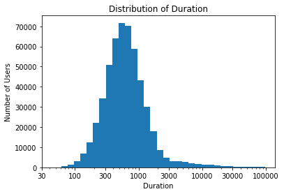

```python
binsize = 0.1
bins = 10 ** np.arange(1.785330, 4.936358 + binsize, binsize)
ticks = [30,100,300,1000,3000,10000,30000,100000]
labls = ['{}'.format(v) for v in ticks]
plt.hist(data = df, x ='duration_sec', bins = bins);
plt.xscale("log");
plt.title('Distribution of Duration')
plt.xlabel('Duration')
plt.ylabel('Number of Users')
plt.xticks(ticks,labls);
```

Note: The above figure shows that the duration of the trip is mostly around 100 sec and 3000 sec. We want to see if the distance or the user type affect the duration and how.

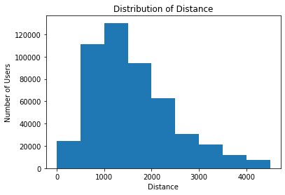

```python
binsize = 500
bins = np.arange(0, (2133+ 1.5*1247)+binsize, binsize)
plt.title('Distribution of Distance')
plt.xlabel('Distance')
plt.ylabel('Number of Users')
plt.hist(data = df_clean, x = 'distance', bins = bins);
```

Note: The above figure shows that the trip distance is mostly arond 0 to 2500. We want to see if the duration or the user type affect the distance and how.

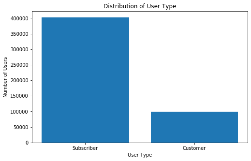

```python
plt.figure(figsize=[8,5])
plt.bar(x = df_clean.	user_type.value_counts().keys(), height = df_clean.	user_type.value_counts() )
plt.title('Distribution of User Type')
plt.xlabel('User Type')
plt.ylabel('Number of Users')
plt.show()
```

Note: The above figure shows that the most user type is subscriber. We want to see how the duration interact with each user type.

## Distribution of User Type

### Discuss the distribution(s) of your variable(s) of interest. Were there any unusual points? Did you need to perform any transformations?

> The distance distribution is not normal distrubution it is right skewed. The most frequent distance is 1300. We want to see if the duration or the user type affect the duration and how.

### Of the features you investigated, were there any unusual distributions? Did you perform any operations on the data to tidy, adjust, or change the form of the data? If so, why did you do this?

> The distance distribution includes extreems values wich affec the analisys

## Bivariate Exploration

```python
#Create correition table
df_clean.corr()
```

|  | duration_sec | start_station_latitude | start_station_longitude | end_station_latitude | end_station_longitude | diff | distance |
| --- | --- | --- | --- | --- | --- | --- | --- |
| duration_sec | 1.000000 | 0.003418 | -0.006922 | 0.004337 | -0.008833 | 0.999987 | 0.104858 |
| start_station_latitude | 0.003418 | 1.000000 | -0.713263 | 0.986970 | -0.719614 | 0.003428 | 0.059322 |
| start_station_longitude | -0.006922 | -0.713263 | 1.000000 | -0.720436 | 0.991573 | -0.006932 | -0.110179 |
| end_station_latitude | 0.004337 | 0.986970 | -0.720436 | 1.000000 | -0.721728 | 0.004347 | 0.065975 |
| end_station_longitude | -0.008833 | -0.719614 | 0.991573 | -0.721728 | 1.000000 | -0.008844 | -0.100665 |
| diff | 0.999987 | 0.003428 | -0.006932 | 0.004347 | -0.008844 | 1.000000 | 0.104896 |
| distance | 0.104858 | 0.059322 | -0.110179 | 0.065975 | -0.100665 | 0.104896 | 1.000000 |

```python
# Create correltion matrix
corrMatrix = df_clean.corr()
```

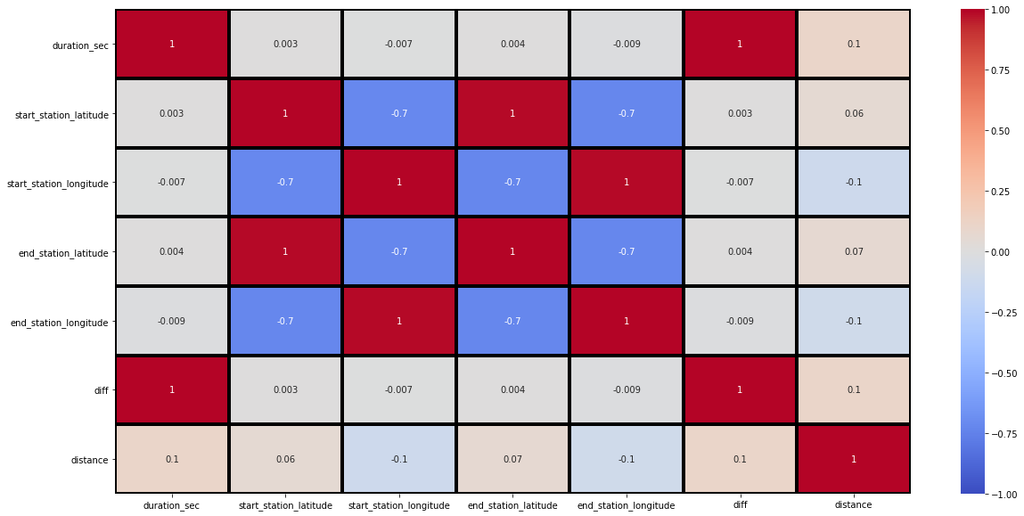

```python
# Plot correlation matrix
plt.figure(figsize=(20,10))

sb.heatmap(corrMatrix, annot = True, fmt='.1g', vmin=-1, vmax=1, center= 0, cmap= 'coolwarm', linewidths=3, linecolor='black')
```

[figure not shown]

```python
plt.figure(figsize=[8,5])
plt.scatter(( df_clean['distance']), df_clean['duration_sec'], alpha = 0.25, marker = '.' )

plt.title('Trip Duration and Age')
plt.xlabel('distance')
plt.ylabel('Duration_sec')
plt.show()
```

Note: As you can see, values are very widespread to see the graph, therefore we will not take values graeter than 20000

```python
# Drop values grater than 20000
df_clean = df_clean[df_clean['distance'] < 20000]
```

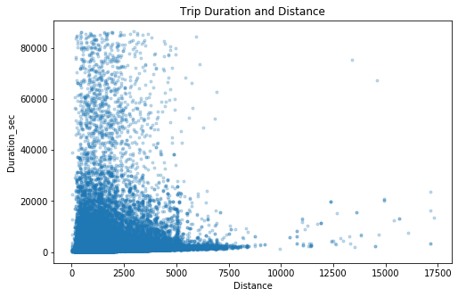

```python
plt.figure(figsize=[8,5])
plt.scatter(( df_clean['distance']), df_clean['duration_sec'], alpha = 0.25, marker = '.' )

plt.title('Trip Duration and Distance')
plt.xlabel('Distance')
plt.ylabel('Duration_sec')
plt.show()
```

Note: The above figure shows that the duration is higher when the distance is less

## Trip Duration and Distance

The duration is higher when the distance is less

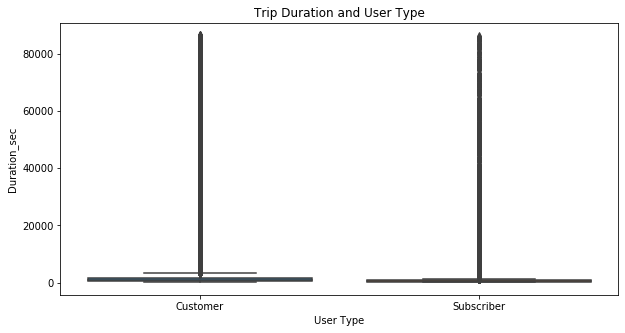

```python
plt.figure(figsize = [10, 5])
sb.boxplot(data = df, x = 'user_type', y = 'duration_sec', )
plt.title('Trip Duration and User Type')
plt.xlabel('User Type')
plt.ylabel('Duration_sec')
plt.show()
```

As you can see, values are very widespread to see a box plot, therefore we will take the interval between -10 and 2000

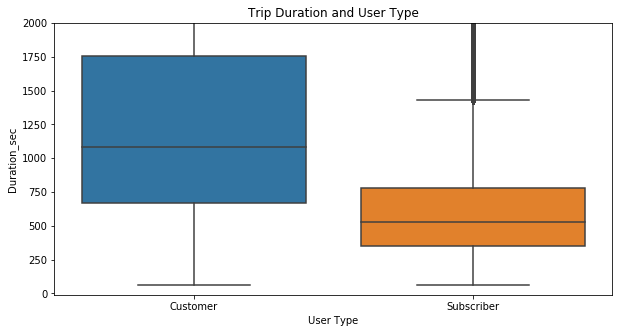

```python
plt.figure(figsize = [10, 5])
sb.boxplot(data = df, x = 'user_type', y = 'duration_sec', )
plt.ylim([-10, 2000])
plt.title('Trip Duration and User Type')
plt.xlabel('User Type')
plt.ylabel('Duration_sec')
plt.show()
```

Note: From the above figure we can see that higher percentage of customer rides longer trips then subscriber although number of subscriber riders are very high then customer.

## Trip Duration and User Type

subscribers ride much shorter trips compared to customers

### Talk about some of the relationships you observed in this part of the investigation. How did the feature(s) of interest vary with other features in the dataset?

> The user type "customer" has an avarge trip duration higher the the user type "subscribers". On the other hand, in the previose figure the number of "subscribers" user type was highr

## Multivariate Exploration

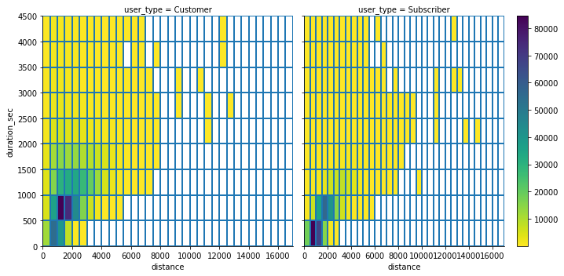

```python
xbin = np.arange(0,17500, 500)
ybin = np.arange(0, 4039.5+500, 500)

g = sb.FacetGrid(data = df_clean, col = 'user_type',height=5)
g.map(plt.hist2d, 'distance','duration_sec',cmin=0.5,cmap = 'viridis_r',bins=[xbin, ybin]);
plt.colorbar();
```

### Were there any interesting or surprising interactions between features?

```python
!jupyter nbconvert exploration.ipynb --to slides --template output-toggle.tpl --post serve
```